# GISER_Joey_PKU

```python
import numpy as np
import matplotlib.pyplot as plt
import pandas as pd
```

# 多种空间聚类方法的原理、实现、用例、对比(更新中)

## KMeans原理及实现

### 算法原理（流程）

1. 预先设定类别数k，开始时随机设立k个聚类中心。
2. 根据各点到聚类中心的距离，将所有点归入距离最近的中心的类别。
3. 对每个类别重新计算聚类中心。
4. 根据新的聚类中心重新分类，然后重复(2) (3) (4)。
5. 直到迭代次数达到设置的上限，或中心的移动小于设置的阈值，停止迭代，输出聚类结果。 ### 时间复杂度估计 如果计算类别数为k，迭代次数为T，样本数为N，二维点的距离计算复杂度记为M\ 由于每次迭代要计算N个样本到k个中心的距离，所以总复杂度为 O(kTNM)。\ 相对于样本数是线性成长的。 ### 主要参数 主要设置的参数是类别数k，另外辅助参数是迭代次数max_iteration和中心偏移的阈值varepsilon。\ 其中最主要的参数是k。常用的确定方法包括肘部法则或轮廓系数。

#### 肘部法则

$$ SSE = \Sigma _{i=1} ^k\Sigma _{c\in C_i}[distance(p,m_i)]^2 $$

#### 轮廓系数

$$ S_i = b_i-a_i\over max(a_i,b_i) $$

$b_i$是i点到最近的不同类别的样本点的平均距离\ $a_i$是i点到同类别样本点的平均距离| 寻找轮廓系数最大的k作为聚类的参数

其中轮廓系数的计算复杂度为$O(n^2)$，开销较大 肘部法则为$O(N)$

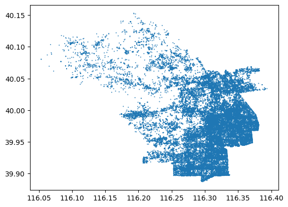

```python
#签到数据的相对路径
path = "haidian_user.tsv"
#仅读取代表坐标的第四第五列
df = pd.read_csv(path, sep='\t', usecols=[4, 5])
#dataframe转为ndarray
X = df.values
plt.scatter(X[:,1],X[:,0],s=[0.2 for i in range(len(X))])
```

```python
from sklearn import cluster
from scipy.spatial.distance import cdist
def ElbowMethod(X):
    """
    肘部法则获取KMeans的最佳K值
    :param X:
    :return:
    """
    sse_result = []
    K = [i+1 for i in range(10)]
    for k in K:
        kmeans = cluster.KMeans(n_clusters=k,n_init=10)
        kmeans.fit(X)
        sse_result.append(sum(np.min(cdist(X, kmeans.cluster_centers_, 'euclidean'), axis=1)) / X.shape[0])
    plt.plot(K, sse_result,marker='.',color='c')
    plt.show()
```

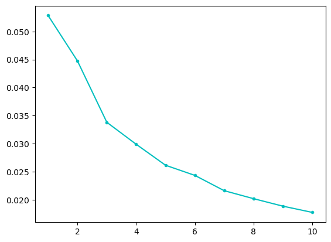

```python
ElbowMethod(X)
```

```python
from sklearn import metrics
def Silhouette(X):
    """
    轮廓系数法确定参数k
    :param X:
    :return:
    """
    silhouette_result = []
    K = [i+3 for i in range(1)]
    for k in K:
        kmeans = cluster.KMeans(n_clusters=k, n_init=10)
        kmeans.fit(X)
        labels = kmeans.labels_
        silhouette_result.append(metrics.silhouette_score(X, labels, metric='euclidean'))
    plt.plot(K, sse_result,marker='.',color='c')
    plt.show()
```

```python
Silhouette(X)#开销太大了，就不跑一遍了
```

### Kmeans的自定义实现

```python
def distance(ctr, points):
    """
    计算一个点到一组点的距离，返回一个array
    :param ctr: 点
    :param points: 一组点
    :return: 记录了距离的array
    """
    distances = np.sqrt(np.power(points-ctr, 2).sum(axis=1))
    return distances

class KMeans:
    def __init__(self, k=3, max_iterations=10, varepsilon=0.005):
        """
        :param k: 类别数
        :param max_iterations: 最大迭代次数
        :param varepsilon: 最小该变量
        """
        self.k = k
        self.max_iterations = max_iterations
        self.varepsilon = varepsilon
        self.labels_ = []
        self.centroids_ = []

    def init_random_CTRoids(self, X):
        """
        从所有样本中随机选取k个样本作为初始的聚类中心
        :param X: 数据集
        :return: 随机的数据中心，一个array，记录的是点而不是id
        """
        n_samples, n_features = np.shape(X)
        self.centroids_ = X[np.random.choice(n_samples,self.k)]

    def closest_CTRoid(self,sample):
        """
        返回距离该样本点最近的一个中心索引
        :param sample: 样本点
        :param CTRoids: 中心点
        :return: 最近的样本点
        """
        distances = distance(self.centroids_,sample)
        closest_i = np.argmin(distances)
        return closest_i

    def create_clusters(self,X):
        """
        对样本进行一轮归类
        :param centroids: 当前的中心点集
        :param X: 数据集
        :return: 返回各类别集合
        """
        n_samples = np.shape(X)[0]
        clusters = [[] for _ in range(self.k)]
        for sample_i, sample in enumerate(X):
            centroid_i = self.closest_CTRoid(sample)
            clusters[centroid_i].append(sample_i)
        return clusters

    def update_centroids(self, clusters, X):
        """
        更新分类中心
        :param clusters: 分类标签
        :param X: 数据集
        :return: 返回新的中心array
        """
        n_features = np.shape(X)[1]
        self.centroids_ = np.zeros((self.k, n_features))
        for i, cluster in enumerate(clusters):
            centroid = np.mean(X[cluster], axis=0)
            self.centroids_[i] = centroid

    def update_cluster_labels(self, clusters, X):
        """
        整理成标签格式
        :return: 返回一个一维数组，是对应id的标签集合
        """
        self.labels_ = np.zeros(np.shape(X)[0])
        for cluster_i, cluster in enumerate(clusters):
            for sample_i in cluster:
                self.labels_[sample_i] = cluster_i

    def fit(self, X):
        """
        对整个数据集X进行Kmeans聚类，返回其聚类的标签
        相当于sklearn的fit_predict
        :param X: 数据集
        :return:
        """
        # 从所有样本中随机选取self.k样本作为初始的聚类中心
        self.init_random_CTRoids(X)

        # 迭代，直到算法收敛(上一次的聚类中心和这一次的聚类中心几乎重合)或者达到最大迭代次数
        for i in range(self.max_iterations):
            # 将所有进行归类，归类规则就是将该样本归类到与其最近的中心
            clusters = self.create_clusters(X)
            former_centroids = self.centroids_

            # 计算新聚类中心
            self.update_centroids(clusters, X)

            # 如果聚类中心几乎没有变化，说明算法已经收敛，退出迭代
            diff = self.centroids_ - former_centroids
            if diff.any() < self.varepsilon:
                break

            print("\r",end="")
            print("kmeans聚类进度:"+((i+1)/self.max_iterations*100).__str__()+"%",end="")

        print("\r")
        print("kmeans聚类完成")

        self.update_cluster_labels(clusters, X)

    def labels(self):
        return self.labels_

    def predict(self,X):
        """
        :return: 返回一个一维数组，是对应id的标签集合
        """
        labels = np.zeros(np.shape(X)[0])
        for i,p in enumerate(X):
            labels[i] = self.closest_CTRoid(p)
        return labels
```

```python
k=3
kmeans = KMeans(k)
kmeans.fit(X)
y = kmeans.labels()
```

```
kmeans聚类进度:100.0%
kmeans聚类完成
```

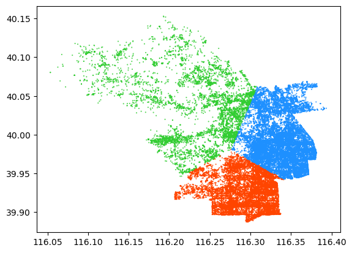

```python
mlist=['orangered','dodgerblue','limegreen']
for i in range(k):
    plt.scatter(X[y == i,1], X[y == i,0],label = i.__str__(),s = [0.2 for i in range(len(X[y==i]))],color=mlist[i])
```

### 调用sklearn的kmeans

```python
kmeans = cluster.KMeans(n_clusters=k,n_init=10)
kmeans.fit(X)
```

```
KMeans(n_clusters=3, n_init=10)
```

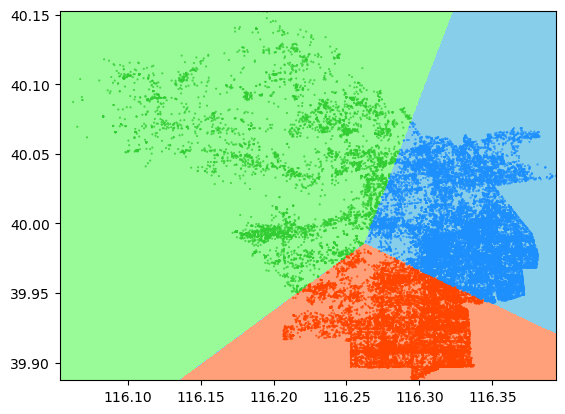

```python
from matplotlib.colors import ListedColormap,LinearSegmentedColormap
clist=['lightsalmon','skyblue','palegreen']
mlist=['orangered','dodgerblue','limegreen']
y = kmeans.labels_
# Plot the decision boundary. For that, we will assign a color to each
x2_min, x2_max = X[:, 0].min() , X[:, 0].max()
x1_min, x1_max = X[:, 1].min() , X[:, 1].max()
h=0.0005
x11, x22 = np.meshgrid(np.arange(x1_min, x1_max, h), np.arange(x2_min, x2_max, h))
Z = kmeans.predict(np.c_[x22.ravel(), x11.ravel()])
# Put the result into a color plot
Z = Z.reshape(x22.shape)
plt.imshow(
    Z,
    #interpolation="nearest",
    extent=(x11.min(), x11.max(), x22.min(), x22.max()),
    cmap=ListedColormap(clist),
    aspect="auto",
    origin="lower",
)
for i in range(k):
    plt.scatter(X[y == i,1], X[y == i,0],label = i.__str__(),s = [0.2 for i in range(len(X[y==i]))],color=mlist[i])
```